# EP07: Métodos no paramétricos para enfrentar datos numéricos problemáticos

Equipo 7

2025-04-29

## Contexto

> En el trabajo de título de una estudiante del DIINF se reportan tiempos de ejecución (en milisegundos) y la cercanía con la solución óptima (en por ciento) de la mejor solución encontrada con tres versiones de un algoritmo genético para resolver instancias del problema del vendedor viajero disponibles en repositorios públicos. Ahora debe enfrentar el análisis de estos datos, por que está solicitando ayuda de las y los estudiantes de Estadística Inferencial.

## Preguntas

Carga de datos:

```r
library(ggpubr)
library(dplyr)
```

```r
library(ggplot2)
library(DescTools)
datos <- read.csv2("EP07 Datos.csv", sep = ",")
head(datos)
```

```
##   instancia n.nodos n.aristas tiempo.A tiempo.B tiempo.C mejor.A mejor.B
## 1         1      50       631   107534   452595   257485   98.72   98.25
## 2         2      50       521    74808   364061   207297   98.99   99.17
## 3         3      50       588    94072   417798   237793    99.1   99.23
## 4         4      50       653   114830   470701   267598   98.69   99.23
## 5         5      50       597    96720   425233   241770    99.8   99.22
## 6         6      50       564    86688   398448   226833   99.19   99.15
##   mejor.C
## 1   99.34
## 2   99.48
## 3    99.1
## 4   97.82
## 5   98.14
## 6   98.04
```

### Pregunta 1

> Observando los datos, la memorista sospecha que hay diferencias significativas en el tiempo de ejecución entre las versiones B y C del algoritmo cuando las instancias tienen 60 o más nodos. ¿Los datos respaldan la intuición de la memorista? Para responder, filtren los datos para tener las instancias con 60 o más nodos y seleccionen las columnas de los tiempos de ejecución de las versiones B y C en formato ancho. Usando como semilla el valor 71, obtenga muestras aleatorias independientes de 22 tiempos registrados por la versión B y 19 tiempos registrados por la versión C del algoritmo. Realicen un análisis estadístico pertinente (enunciar hipótesis, revisar condiciones, seleccionar pruebas ómnibus y post-hoc según corresponda) para responder la pregunta planteada, utilizando pruebas no paramétricas de ser necesario.

Prinero se obtienen las muestras para las instancias B y C.

```r
instancias60 <- datos[datos$n.nodos >= 60, ]

set.seed(71)
muestraB <- sample(instancias60$tiempo.B, 22)
muestraC <- sample(instancias60$tiempo.C, 19)
```

Dado que se quiere investigar la diferencia entre las medias de dos muestras aleatorias a priori se puede intentar hacer un test t-Student para la diferencia entre dos muestras independientes, vemos que se cumple la condición de observaciones y muestras independientes, se verá a continuación la condición de normalidad de cada muestra.

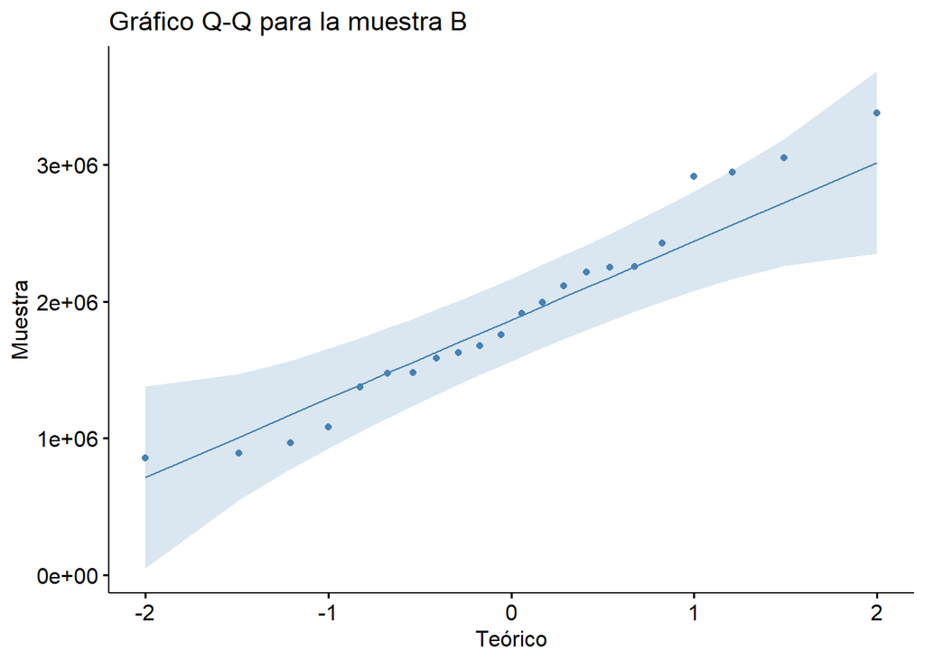

```r
gB <- ggqqplot(
  data = data.frame(muestraB),
  x = "muestraB",
  color = "steelblue",
  xlab = "Teórico",
  ylab = "Muestra",
  title = "Gráfico Q-Q para la muestra B"
)
print(gB)
```

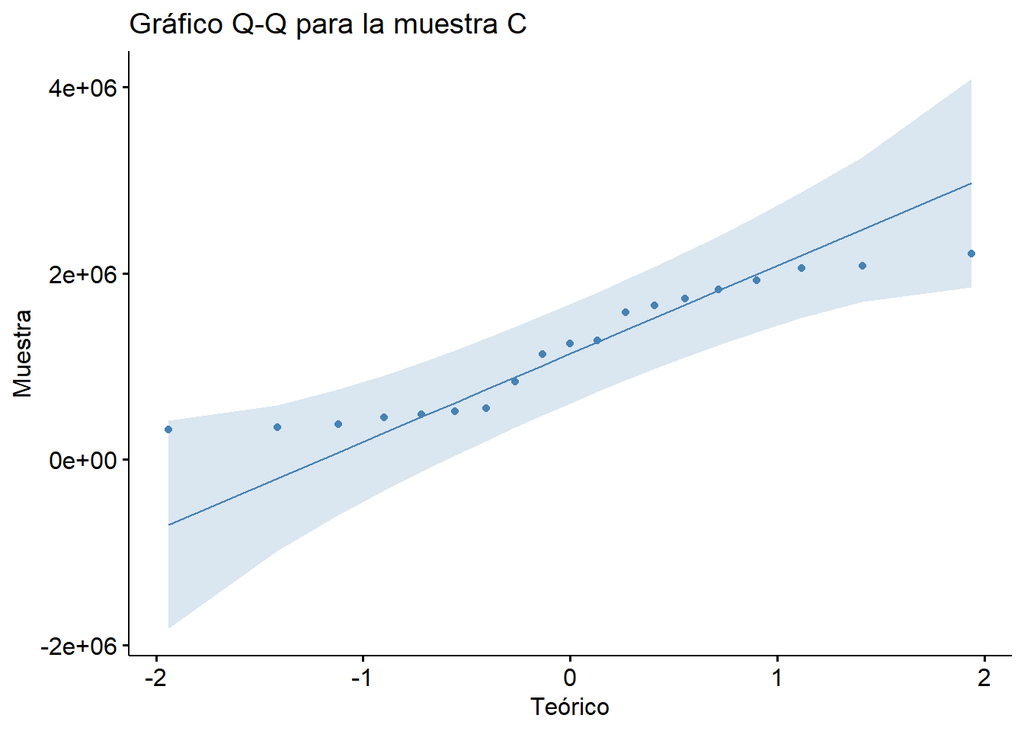

```r
gC <- ggqqplot(
  data = data.frame(muestraC),
  x = "muestraC",
  color = "steelblue",
  xlab = "Teórico",
  ylab = "Muestra",
  title = "Gráfico Q-Q para la muestra C"
)
print(gC)
```

```r
normB <- shapiro.test(muestraB)
normC <- shapiro.test(muestraC)

pvalorB <- normB$p.value
pvalorC <- normC$p.value
```

Ahora, se verán las hipótesis a docimar.

- $H_0$: en promedio, no hay diferencias en los tiempos entre la versión B y C del algoritmo genético.
- $H_A$: existe una diferencia significativa en los tiempos de ejecución entre la versión B y C del algoritmo genético.

```r
prueba <- wilcox.test(muestraB, muestraC, alternative = "two.sided", conf.level = 0.95)
pvalorPrueba <- prueba$p.value
```

Con la prueba hecha, se obtiene un p-valor de $0.0041255$, esto finalmente nos indica que rechazamos con un $95\%$ de confianza la hipótesis nula, por lo que los datos sugieren que existe una diferencia significativa en los tiempos de ejecucion entre la versión B y C del algoritmo genético.

Se toma en consideración que es posible utilizar una transformación de Box-Cox para ambas muestras para realizar la prueba t-Student correspondiente.

```r
lambdaB <- BoxCoxLambda(muestraB, lower = -4, upper = 4)
lambdaC <- BoxCoxLambda(muestraC, lower = -4, upper = 4)

transformacionB <- BoxCox(muestraB, lambdaB)
transformacionC <- BoxCox(muestraC, lambdaC)

diferencia <- transformacionB - transformacionC
pruebastudent <- t.test(x = transformacionB, y = transformacionC, paired = FALSE, alternative = "two.sided", mu = 0, conf.level = 0.05)
print(pruebastudent)
```

```
##
##  Welch Two Sample t-test
##
## data:  transformacionB and transformacionC
## t = -6.1093, df = 18, p-value = 9.016e-06
## alternative hypothesis: true difference in means is not equal to 0
## 5 percent confidence interval:
##  -135927463 -133127092
## sample estimates:
##    mean of x    mean of y
## 1.585843e+01 1.345273e+08
```

### Pregunta 2

> La memorista también sospecha que, al comparar las mismas instancias de iguales características, las mejores soluciones encontradas por las versiones B y C tienen rendimientos distintos. ¿Estará en lo cierto? Para responder, filtren los datos para tener las instancias con 60 o más nodos y seleccionen las columnas con el mejor rendimiento de las versiones B y C en formato ancho. Usando como semilla el valor 33, obtengan una muestra aleatoria de 20 instancias. Realicen un análisis estadístico pertinente (enunciar hipótesis, revisar condiciones, seleccionar pruebas ómnibus y post-hoc según corresponda) para responder la pregunta planteada, utilizando pruebas no paramétricas de ser necesario.

```r
#datos
datos <- read.csv("EP07 Datos.csv")

#filtrar los datos con 60 o mas nodos
rendimiento <- datos %>%
  filter(n.nodos >= 60) %>%
  select(mejor.B, mejor.C)

#fijar semilla y tomar muestra de 20 instancias
set.seed(33)
muestra <- rendimiento %>% slice_sample(n = 20)


#evaluar normalidad de las diferencias (Shapiro-Wilk)

diferencias <- muestra$mejor.B - muestra$mejor.C
shapiro_resultado <- shapiro.test(diferencias)

cat("\nResultado de la prueba de normalidad (Shapiro-Wilk):\n")
```

```
##
## Resultado de la prueba de normalidad (Shapiro-Wilk):
```

```r
print(shapiro_resultado)
```

```
##
##  Shapiro-Wilk normality test
##
## data:  diferencias
## W = 0.97256, p-value = 0.8077
```

```r
#prueba de Wilcoxon para muestras pareadas

wilcoxon_resultado <- wilcox.test(muestra$mejor.B, muestra$mejor.C, paired = TRUE)
cat("\nResultado de la prueba de Wilcoxon:\n")
```

```
##
## Resultado de la prueba de Wilcoxon:
```

```r
print(wilcoxon_resultado)
```

```
##
##  Wilcoxon signed rank test with continuity correction
##
## data:  muestra$mejor.B and muestra$mejor.C
## V = 46.5, p-value = 0.03035
## alternative hypothesis: true location shift is not equal to 0
```

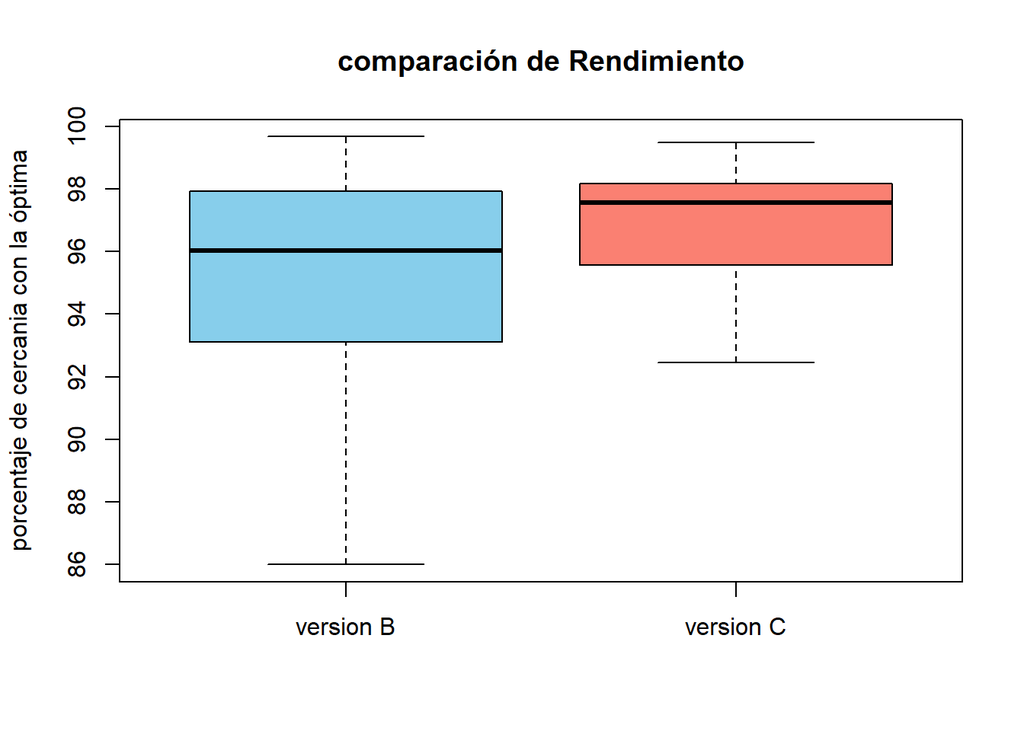

```r
#grafico para visualizar

boxplot(muestra$mejor.B, muestra$mejor.C,
        names = c("version B", "version C"),
        main = "comparación de Rendimiento",
        ylab = "porcentaje de cercania con la óptima",
        col = c("skyblue", "salmon"))
```

```r
cat("\n")
```

#Conclusión La prueba de Wilcoxon para muestras pareadas indica que existe una diferencia significativa entre los rendimientos de las versiones B y C. Esto sugiere que la memorista tiene razón al sospechar que las mejores soluciones encontradas por ambas versiones tienen rendimientos distintos.

### Pregunta 3

> La memorista sospecha que hay diferencias significativas en el tiempo de ejecución entre las versiones del algoritmo cuando las instancias de prueba tienen 60 o más nodos. ¿Los datos respaldan la intuición de la memorista? Para responder, filtren los datos para tener las instancias con 60 o más nodos y seleccionen las columnas con los tiempos de ejecución registrados (en formato ancho). Usando como semilla el valor 31, obtengan muestras aleatorias independientes de 15, 14 y 13 tiempos registrados por las versiones A, B y C, respectivamente. Realicen un análisis estadístico pertinente (enunciar hipótesis, revisar condiciones, seleccionar pruebas ómnibus y post-hoc según corresponda) para responder la pregunta planteada, utilizando pruebas no paramétricas de ser necesario.

```r
#Cargar librerías
library(dplyr)
library(ggplot2)
library(FSA)         # Para test post-hoc de Dunn
library(rcompanion)  # Para compatibilidad de Dunn's test

#datos
datos <- read.csv("EP07 Datos.csv")

#filtrar instancias con 60 o mas nodos y seleccionar tiempos
tiempos <- datos %>%
  filter(n.nodos >= 60) %>%
  select(tiempo.A, tiempo.B, tiempo.C)

#fijar semilla y tomar las muestras
set.seed(31)
muestra_A <- tiempos$tiempo.A %>% sample(15)
muestra_B <- tiempos$tiempo.B %>% sample(14)
muestra_C <- tiempos$tiempo.C %>% sample(13)

#crear data frame largo para análisis
muestra <- data.frame(
  tiempo = c(muestra_A, muestra_B, muestra_C),
  version = factor(c(
    rep("A", 15),
    rep("B", 14),
    rep("C", 13))))

#prueba de normalidad por grupo
cat("Prueba de normalidad por versión:\n")
```

```
## Prueba de normalidad por versión:
```

```r
by(muestra$tiempo, muestra$version, shapiro.test)
```

```
## muestra$version: A
##
##  Shapiro-Wilk normality test
##
## data:  dd[x, ]
## W = 0.86004, p-value = 0.02417
##
## ------------------------------------------------------------
## muestra$version: B
##
##  Shapiro-Wilk normality test
##
## data:  dd[x, ]
## W = 0.96567, p-value = 0.8141
##
## ------------------------------------------------------------
## muestra$version: C
##
##  Shapiro-Wilk normality test
##
## data:  dd[x, ]
## W = 0.94103, p-value = 0.4704
```

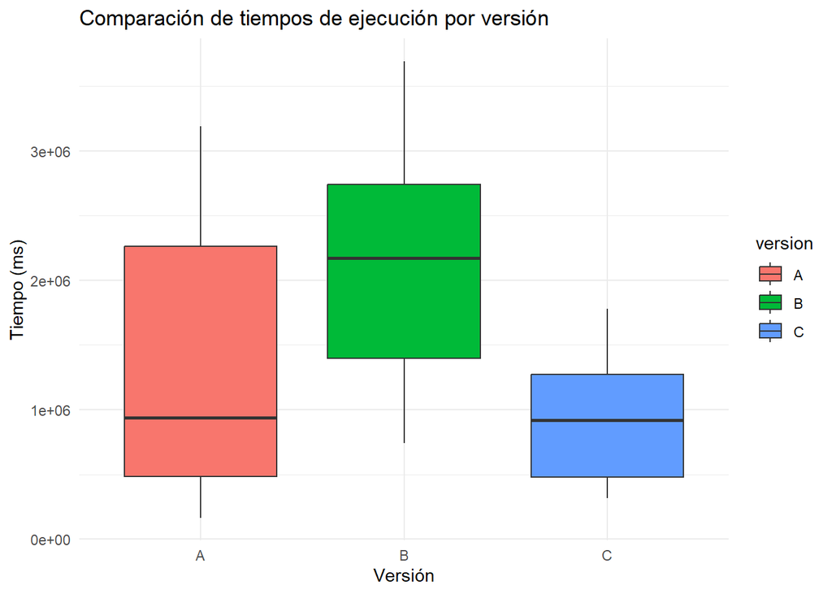

```r
#grafico de tiempos
ggplot(muestra, aes(x = version, y = tiempo, fill = version)) +
  geom_boxplot() +
  labs(title = "Comparación de tiempos de ejecución por versión",
       y = "Tiempo (ms)", x = "Versión") +
  theme_minimal()
```

```r
#Prueba de Kruskal-Wallis
kw_resultado <- kruskal.test(tiempo ~ version, data = muestra)
cat("\nResultado de la prueba de Kruskal-Wallis:\n")
```

```
##
## Resultado de la prueba de Kruskal-Wallis:
```

```r
print(kw_resultado)
```

```
##
##  Kruskal-Wallis rank sum test
##
## data:  tiempo by version
## Kruskal-Wallis chi-squared = 11.449, df = 2, p-value = 0.003265
```

```r
#Test post-hoc de Dunn si Kruskal-Wallis es significativo
if (kw_resultado$p.value < 0.05) {
  cat("\nDado que el p-valor es menor a 0.05, realizamos comparación post-hoc (Dunn):\n")
  dunn_resultado <- dunnTest(tiempo ~ version, data = muestra, method = "bonferroni")
  print(dunn_resultado)
}
```

```
##
## Dado que el p-valor es menor a 0.05, realizamos comparación post-hoc (Dunn):
```

```
## Dunn (1964) Kruskal-Wallis multiple comparison
```

```
##   p-values adjusted with the Bonferroni method.
```

```
##   Comparison          Z     P.unadj       P.adj
## 1      A - B -2.6677430 0.007636263 0.022908790
## 2      A - C  0.5703297 0.568454115 1.000000000
## 3      B - C  3.1349749 0.001718688 0.005156065
```

```r
cat("\n")
```

### Pregunta 4

> La memorista también sospecha que, al comparar las mismas instancias con iguales características, las mejores soluciones encontradas por las diferentes versiones del algoritmo tienen rendimientos distintos. ¿Estará en lo cierto? Para responder, filtren los datos para tener las instancias con 60 o más nodos y seleccionen las columnas con los mejores rendimientos registrados. Usando como semilla el valor 73, obtengan una muestra aleatoria de 22 instancias. Realicen un análisis estadístico pertinente (enunciar hipótesis, revisar condiciones, seleccionar pruebas ómnibus y post-hoc según corresponda) para responder la pregunta planteada, utilizando pruebas no paramétricas de ser necesario.

En primer lugar se filtran y se sacan muestras de los datos.

```r
instancias60 <- datos[datos$n.nodos >= 60, ]

set.seed(73)
muestraA <- sample(instancias60$mejor.A, 22)
muestraB <- sample(instancias60$mejor.B, 22)
muestraC <- sample(instancias60$mejor.C, 22)
```

Luego, al tener tres muestras independientes del mismo dataset, se estima pertinente hacer un análisis no paramétrico para las 3 muestras se hará un test de Kruskal-Walis.

Ántes, se verifican las condiciones: - Escala ordinal de la variable mejor tiempo. - Observaciones son independientes entre sí. - La variable independiente tiene por lo menos dos niveles.

```r
tiempo <- c(muestraA, muestraB, muestraC)
criterio <- c(rep("A", length(muestraA)), rep("B", length(muestraB)), rep("C", length(muestraC)))
criterio <- factor(criterio)
datos <- data.frame(tiempo, criterio)

prueba <- kruskal.test(tiempo ~ criterio, data = datos)
print(prueba)
```

```
##
##  Kruskal-Wallis rank sum test
##
## data:  tiempo by criterio
## Kruskal-Wallis chi-squared = 10.026, df = 2, p-value = 0.00665
```

```r
pvalorkruskal = prueba$p.value
```

Con este resultado, vemos pertinente hacer un procedimiento post-hoc de Benjamini-Hochberg:

```r
posthoc <- pairwise.wilcox.test(datos[["tiempo"]],datos[["criterio"]] , p.adjust.method = "BH", paired = FALSE, exact=FALSE)
print(posthoc)
```

```
##
##  Pairwise comparisons using Wilcoxon rank sum test with continuity correction
##
## data:  datos[["tiempo"]] and datos[["criterio"]]
##
##   A      B
## B 0.0093 -
## C 0.3072 0.0375
##
## P value adjustment method: BH
```

Finalmente, con el análisis estadístico ómnibus se concluye que la mayor diferencia existe entre el algoritmo A y B, un p-valor de $0.0093$.